# Praca domowa pierwsza - z fragmentami w formie wiersza

Dominik Rafacz

Października dzień 14, roku Pańskiego 2019

# Na wykresów tworzenia czasów spojrzenia

Diagramy, wykresy i “charty” - w eRze to nie są żarty!

Skoro ich tyle już generujemy, niechże może chociaż wiemy

ile to czasu zajmuje i jak na naszą wieczność wpływuje!

Porównamy trzy metody - w subiektywnej kolejności użycia wygody

będą to pakiet `ggplot2` (swego rodzaju celebryta),

do tego `lattice`, nieco leciwy, trącący myszką, na czubku siwy

i prawdziwe średniowiecze - `graphics`, ówczesny szczyt myśli człowieczej.

Testować będziemy poniższe wizualizacje

Na zbiorze z OpenML, losowym, macie rację

Wierszy: trzydzieści cztery tysiące czterysta sześćdziesiąt pięć

(coraz gorsze moje rymy, ale właśnie wpadł z wizytą zięć),

kolumn - o jedenaście mniej niż sto trzydzieści

i sam nie wiem, co się w tym datasecie mieści.

## Wykresy rozproszenia podstawą grafiką się bawienia

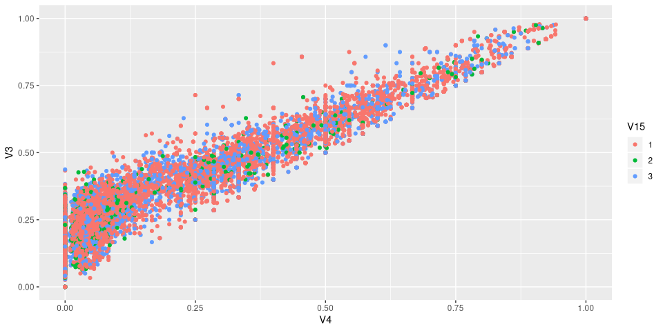

```r
ggplot(data = dset, aes(x = V4, y = V3, color = V15)) +
  geom_point()
```

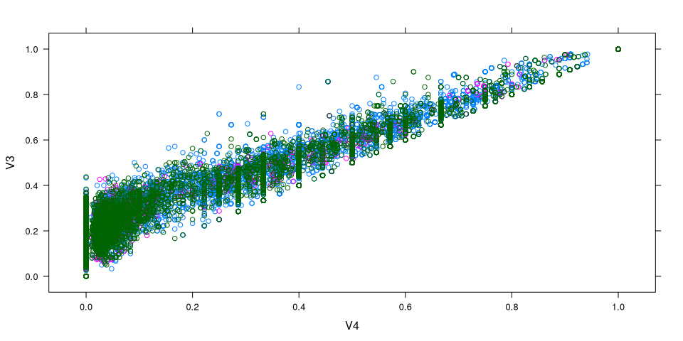

```r
xyplot(V3~V4, dset, groups = V15)
```

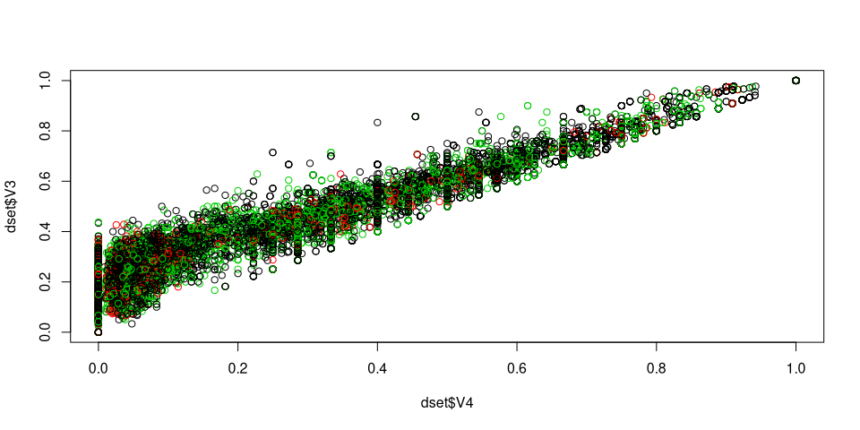

```r
plot(dset$V4, dset$V3, col = dset$V15)
```

## Histogramy (z podziałem na klasy) do wizualizacji gęstości i masy

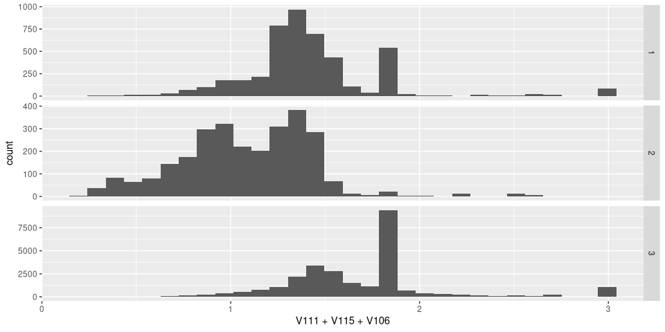

```r
ggplot(data = dset, aes(x = V111 + V115 + V106)) +
  geom_histogram() +
  facet_grid(V80~., scales = "free")
```

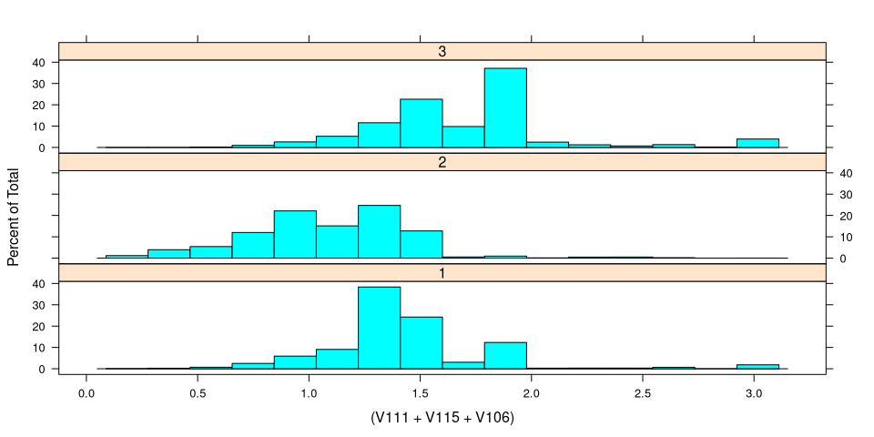

```r
histogram(~(V111 + V115 + V106) | V80, data = dset, layout = c(1,3))
```

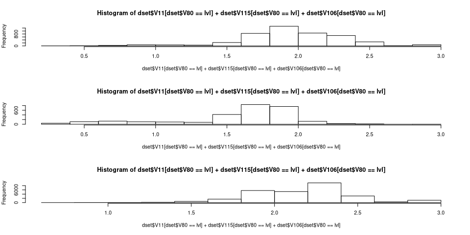

```r
par(mfrow = c(3, 1))
for (lvl in as.numeric(levels(dset$V80))) {
  hist(dset$V11[dset$V80 == lvl] +
         dset$V115[dset$V80 == lvl] +
         dset$V106[dset$V80 == lvl])
}
```

```r
rm(lvl)
par(mfrow = c(1, 1))
```

## Wykresy pudełkowe - szast prast i gotowe!

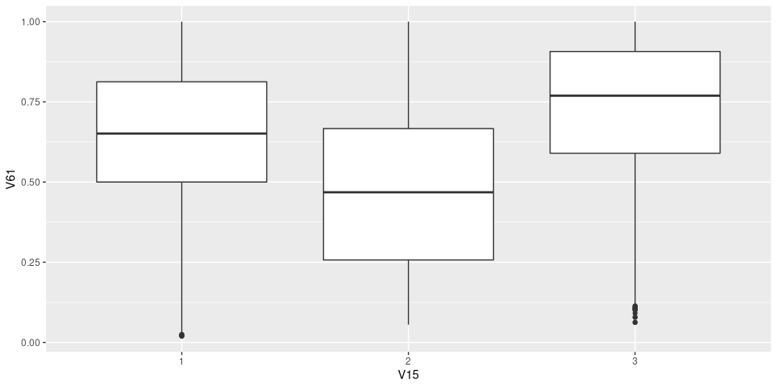

```r
ggplot(data = dset, aes(x = V15, y = V61)) +
  geom_boxplot()
```

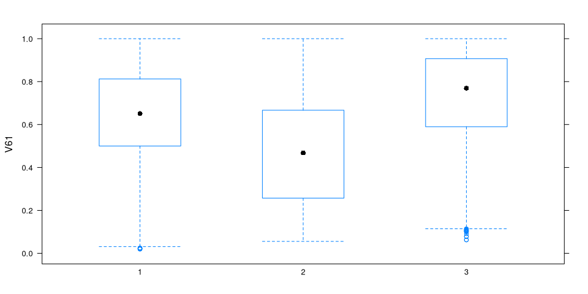

```r
bwplot(V61~V15, data = dset)
```

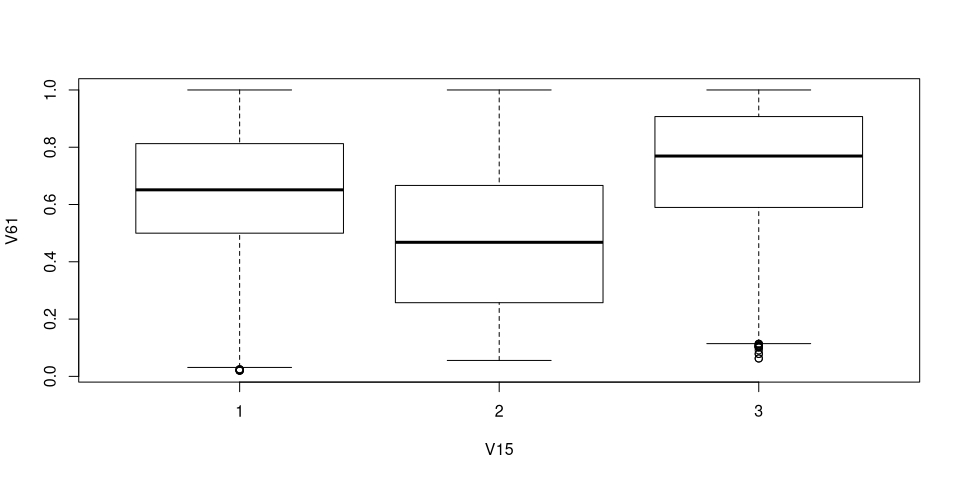

```r
boxplot(V61~V15, data = dset)
```

## Zależność cechy rozkładu gęstości od zmiennej niezależnej wartości

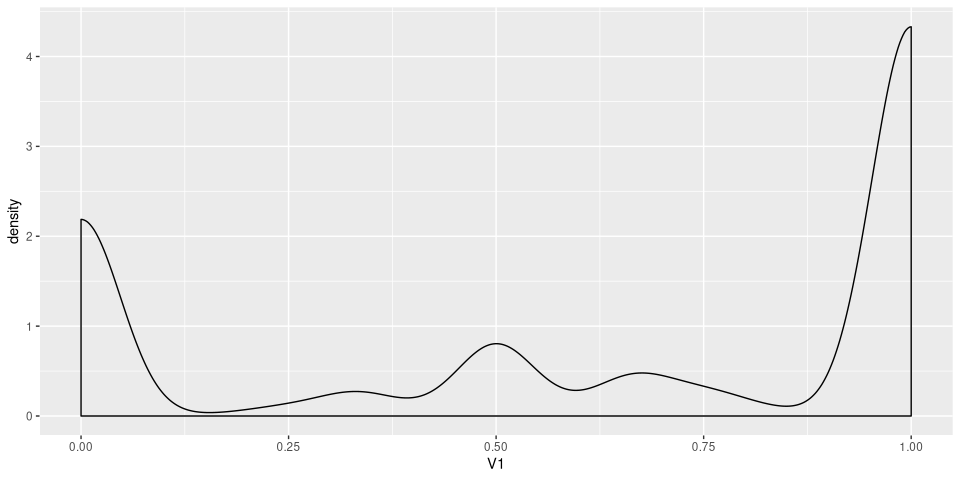

```r
ggplot(data = dset, aes(x = V1)) +
  geom_density()
```

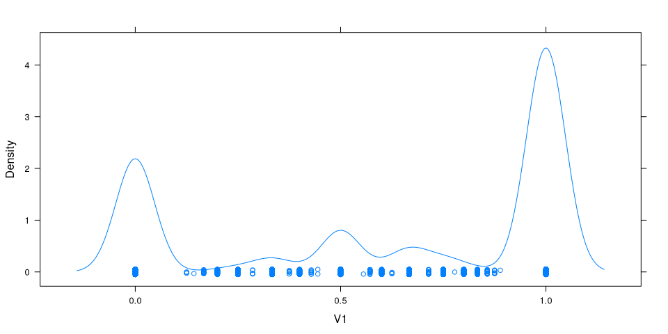

```r
densityplot(~V1, data = dset)
```

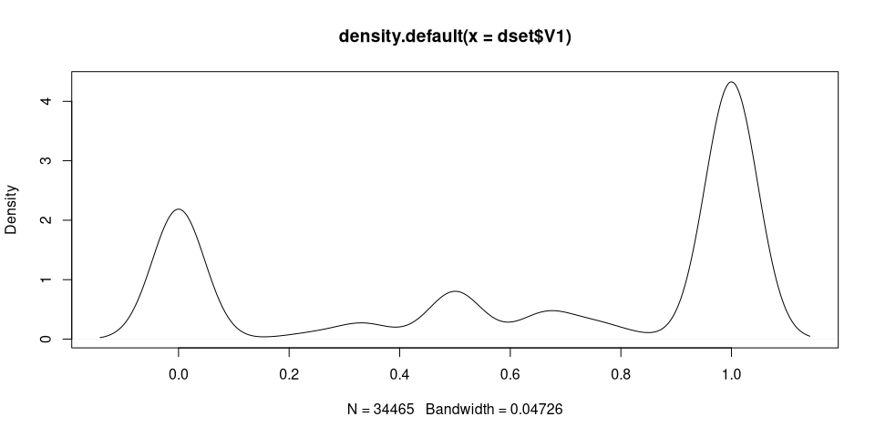

```r
plot(density(dset$V1))
```

## Banalny i mdły mapy ciepła przykład szybki (choć zły)

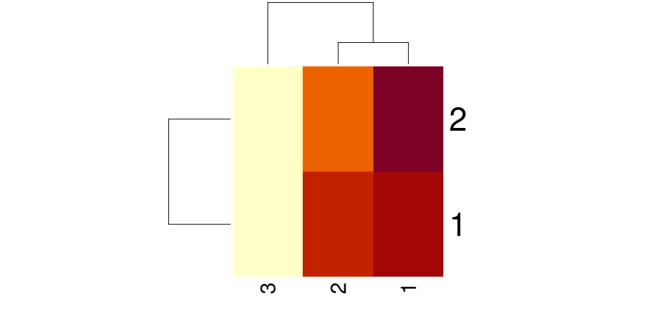

```r
heatmap(matrix(pull(
  summarise(
    group_by(dset, V116, Class), n = n()), n), 2))
```

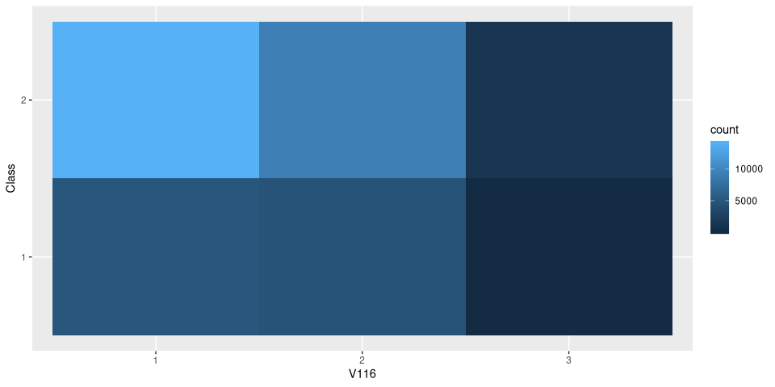

```r
ggplot(dset, aes(x = V116, y = Class)) +
  geom_bin2d()
```

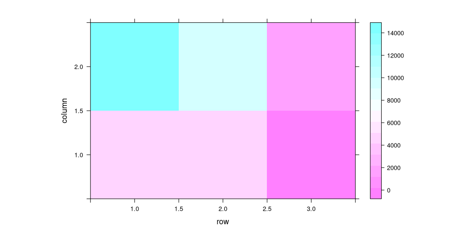

```r
levelplot(t(matrix(pull(
  summarise(
    group_by(dset, V116, Class), n = n()), n), 2)), aspect = "iso")
```

# Wyniki benchmarku (o Święty Marku!)

Każdy z wykresów generujemy dwadzieścia razy.

Z wyniku bierzemy medianę by gładzić garbage collectingu zmazy.

(używamy do tego

`microbenchmarku`, kolego)

Co nam wyszło - popatrzeć proszę

Na - a jakże - wykresach informacje te nanoszę:

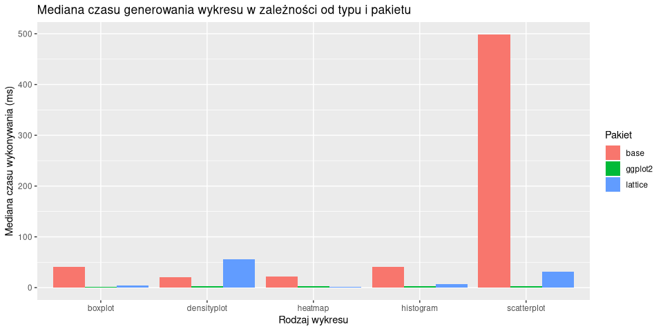

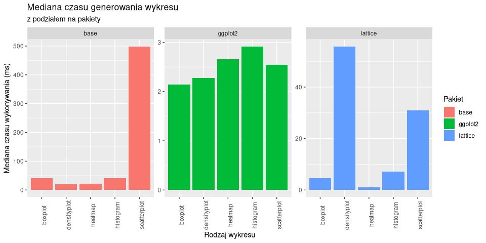

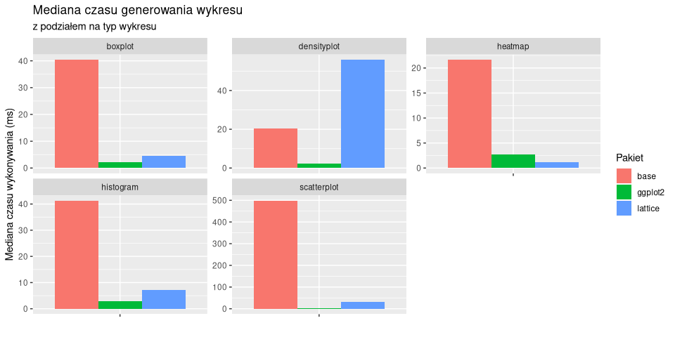

Wnioski są proste - `ggplot2` rządzi!

Kto używa czego innego, ten błądzi!

Dodatkowe uwagi, niekoniecznie wierszem:

- Preprocessing danych konieczny do uzyskania heatmapy w przypadku bazowego wykresu oraz wersji z pakietu `lattice` dla heatmapy nie jest uwzględniony w czasie wykonywania wykresu.
- Wykresy są renderowane bez dodatkowych ustawień typu: tytuły, legendy, opisy i zakresy osi. Parametry tego typu są ustawione domyślnie.